# Assignment 4 - k-Means Clustering

Zach Ours

2026-10-28

# Introduction

In this assignment, I used k-Means clustering to group 21 pharmaceutical companies based on their financial information. The goal was to see which companies have similar financial characteristics.

# Question A

I used the nine financial variables to create the clusters. I standardized the data because the variables have different scales. I used k-Means because it groups companies with similar financial information. All nine variables were given equal weight after standardizing.

```r
pharma <- read.csv("Pharmaceuticals.csv")

head(pharma)
```

```
##   Symbol                Name Market_Cap Beta PE_Ratio  ROE  ROA Asset_Turnover
## 1    ABT Abbott Laboratories      68.44 0.32     24.7 26.4 11.8            0.7
## 2    AGN      Allergan, Inc.       7.58 0.41     82.5 12.9  5.5            0.9
## 3    AHM        Amersham plc       6.30 0.46     20.7 14.9  7.8            0.9
## 4    AZN     AstraZeneca PLC      67.63 0.52     21.5 27.4 15.4            0.9
## 5    AVE             Aventis      47.16 0.32     20.1 21.8  7.5            0.6
## 6    BAY            Bayer AG      16.90 1.11     27.9  3.9  1.4            0.6
##   Leverage Rev_Growth Net_Profit_Margin Median_Recommendation Location Exchange
## 1     0.42       7.54              16.1          Moderate Buy       US     NYSE
## 2     0.60       9.16               5.5          Moderate Buy   CANADA     NYSE
## 3     0.27       7.05              11.2            Strong Buy       UK     NYSE
## 4     0.00      15.00              18.0         Moderate Sell       UK     NYSE
## 5     0.34      26.81              12.9          Moderate Buy   FRANCE     NYSE
## 6     0.00      -3.17               2.6                  Hold  GERMANY     NYSE
```

```r
financial <- pharma[, 3:11]

financial_scaled <- scale(financial)

head(financial_scaled)
```

```
##      Market_Cap        Beta    PE_Ratio         ROE        ROA Asset_Turnover
## [1,]  0.1840960 -0.80125356 -0.04671323  0.04009035  0.2416121  -5.121077e-16
## [2,] -0.8544181 -0.45070513  3.49706911 -0.85483986 -0.9422871   9.225312e-01
## [3,] -0.8762600 -0.25595600 -0.29195768 -0.72225761 -0.5100700   9.225312e-01
## [4,]  0.1702742 -0.02225704 -0.24290879  0.10638147  0.9181259   9.225312e-01
## [5,] -0.1790256 -0.80125356 -0.32874435 -0.26484883 -0.5664461  -4.612656e-01
## [6,] -0.6953818  2.27578267  0.14948233 -1.45146000 -1.7127612  -4.612656e-01
##        Leverage Rev_Growth Net_Profit_Margin
## [1,] -0.2120979 -0.5277675        0.06168225
## [2,]  0.0182843 -0.3811391       -1.55366706
## [3,] -0.4040831 -0.5721181       -0.68503583
## [4,] -0.7496565  0.1474473        0.35122600
## [5,] -0.3144900  1.2163867       -0.42597037
## [6,] -0.7496565 -1.4971443       -1.99560225
```

I used the elbow method to help decide how many clusters to create.

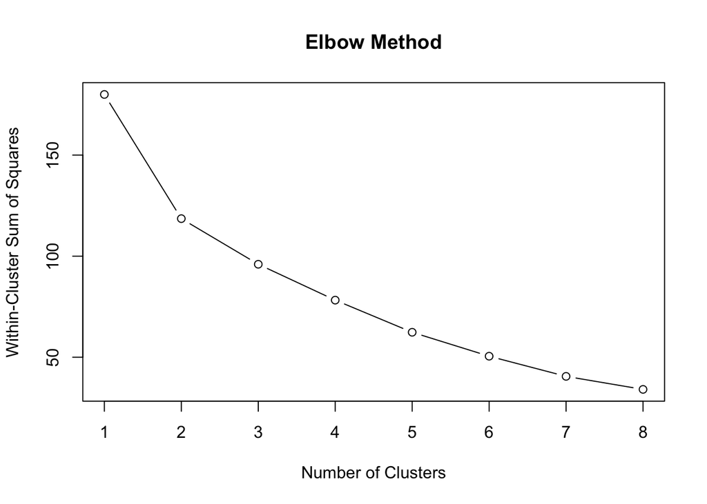

```r
set.seed(123)

wss <- numeric(8)

for (k in 1:8) {
  model <- kmeans(financial_scaled, centers = k, nstart = 25)
  wss[k] <- model$tot.withinss
}

plot(1:8, wss,
     type = "b",
     xlab = "Number of Clusters",
     ylab = "Within-Cluster Sum of Squares",
     main = "Elbow Method")
```

I chose three clusters because this gave me a reasonable number of groups to compare without having too many small clusters. I used 25 random starting points to help get a consistent result.

```r
set.seed(123)

km <- kmeans(financial_scaled, centers = 3, nstart = 25)

pharma$Cluster <- km$cluster

table(pharma$Cluster)
```

```
##
##  1  2  3
##  4 11  6
```

```r
pharma[, c("Name", "Cluster")]
```

```
##                                  Name Cluster
## 1                 Abbott Laboratories       2
## 2                      Allergan, Inc.       1
## 3                        Amersham plc       1
## 4                     AstraZeneca PLC       2
## 5                             Aventis       3
## 6                            Bayer AG       1
## 7        Bristol-Myers Squibb Company       2
## 8                        Chattem, Inc       3
## 9               Elan Corporation, plc       3
## 10              Eli Lilly and Company       2
## 11                GlaxoSmithKline plc       2
## 12                   IVAX Corporation       3
## 13                  Johnson & Johnson       2
## 14 Medicis Pharmaceutical Corporation       3
## 15                  Merck & Co., Inc.       2
## 16                        Novartis AG       2
## 17                         Pfizer Inc       2
## 18              Pharmacia Corporation       1
## 19        Schering-Plough Corporation       2
## 20       Watson Pharmaceuticals, Inc.       3
## 21                              Wyeth       2
```

# Question B

I calculated the average financial values for each cluster to compare the groups.

```r
cluster_means <- aggregate(financial,
                           by = list(Cluster = pharma$Cluster),
                           FUN = mean)

round(cluster_means, 2)
```

```
##   Cluster Market_Cap Beta PE_Ratio  ROE   ROA Asset_Turnover Leverage
## 1       1      21.75 0.60    46.90 11.3  5.10           0.75     0.30
## 2       2      97.11 0.43    20.95 35.7 14.95           0.80     0.33
## 3       3       9.23 0.65    19.43 17.3  5.98           0.48     1.25
##   Rev_Growth Net_Profit_Margin
## 1       7.01              6.65
## 2      10.16             20.17
## 3      23.49             13.52
```

```r
round(km$centers, 2)
```

```
##   Market_Cap  Beta PE_Ratio   ROE   ROA Asset_Turnover Leverage Rev_Growth
## 1      -0.61  0.27     1.31 -0.96 -1.02           0.23    -0.36      -0.58
## 2       0.67 -0.36    -0.28  0.66  0.83           0.46    -0.33      -0.29
## 3      -0.83  0.48    -0.37 -0.56 -0.85          -1.00     0.85       0.92
##   Net_Profit_Margin
## 1             -1.38
## 2              0.68
## 3             -0.33
```

Cluster 1 had lower profitability and the highest average P/E ratio. Cluster 2 had the largest companies and the highest average return on equity and profit margin. Cluster 3 had smaller companies with the highest revenue growth and leverage. This shows that each cluster has different financial strengths and weaknesses.

# Question C

I compared the clusters using median recommendations, headquarters locations, and stock exchanges. These variables were not used to create the clusters.

```r
table(pharma$Cluster, pharma$Median_Recommendation)
```

```
##
##     Hold Moderate Buy Moderate Sell Strong Buy
##   1    2            1             0          1
##   2    6            3             2          0
##   3    1            3             2          0
```

```r
table(pharma$Cluster, pharma$Location)
```

```
##
##     CANADA FRANCE GERMANY IRELAND SWITZERLAND UK US
##   1      1      0       1       0           0  1  1
##   2      0      0       0       0           1  2  8
##   3      0      1       0       1           0  0  4
```

```r
table(pharma$Cluster, pharma$Exchange)
```

```
##
##     AMEX NASDAQ NYSE
##   1    0      0    4
##   2    0      0   11
##   3    1      1    4
```

Cluster 1 had companies from several different countries, and all four were listed on the NYSE. Cluster 2 was mostly made up of US companies, and all 11 were listed on the NYSE. Cluster 3 was also mostly US companies, but it included companies listed on NASDAQ and AMEX. There were some differences in recommendations, but no clear pattern across all three clusters.

# Question D

I used the average financial values to give each cluster a name based on its characteristics.

```r
for (i in 1:3) {
  cat("\nCluster", i, "\n")

  cat("Average Market Cap:",
      round(cluster_means$Market_Cap[i], 2), "\n")

  cat("Average ROE:",
      round(cluster_means$ROE[i], 2), "\n")

  cat("Average Revenue Growth:",
      round(cluster_means$Rev_Growth[i], 2), "\n")
}
```

```
##
## Cluster 1
## Average Market Cap: 21.75
## Average ROE: 11.3
## Average Revenue Growth: 7.01
##
## Cluster 2
## Average Market Cap: 97.11
## Average ROE: 35.7
## Average Revenue Growth: 10.16
##
## Cluster 3
## Average Market Cap: 9.23
## Average ROE: 17.3
## Average Revenue Growth: 23.49
```

```r
pharma$Cluster_Name <- c(
  "Lower Profitability Companies",
  "Large Profitable Companies",
  "Smaller Growth Companies"
)[pharma$Cluster]

pharma[, c("Name", "Cluster", "Cluster_Name")]
```

```
##                                  Name Cluster                  Cluster_Name
## 1                 Abbott Laboratories       2    Large Profitable Companies
## 2                      Allergan, Inc.       1 Lower Profitability Companies
## 3                        Amersham plc       1 Lower Profitability Companies
## 4                     AstraZeneca PLC       2    Large Profitable Companies
## 5                             Aventis       3      Smaller Growth Companies
## 6                            Bayer AG       1 Lower Profitability Companies
## 7        Bristol-Myers Squibb Company       2    Large Profitable Companies
## 8                        Chattem, Inc       3      Smaller Growth Companies
## 9               Elan Corporation, plc       3      Smaller Growth Companies
## 10              Eli Lilly and Company       2    Large Profitable Companies
## 11                GlaxoSmithKline plc       2    Large Profitable Companies
## 12                   IVAX Corporation       3      Smaller Growth Companies
## 13                  Johnson & Johnson       2    Large Profitable Companies
## 14 Medicis Pharmaceutical Corporation       3      Smaller Growth Companies
## 15                  Merck & Co., Inc.       2    Large Profitable Companies
## 16                        Novartis AG       2    Large Profitable Companies
## 17                         Pfizer Inc       2    Large Profitable Companies
## 18              Pharmacia Corporation       1 Lower Profitability Companies
## 19        Schering-Plough Corporation       2    Large Profitable Companies
## 20       Watson Pharmaceuticals, Inc.       3      Smaller Growth Companies
## 21                              Wyeth       2    Large Profitable Companies
```

I named Cluster 1 Lower Profitability Companies because it had the lowest average profit margin. Cluster 2 was named Large Profitable Companies because it had the highest market capitalization and return on equity. Cluster 3 was named Smaller Growth Companies because it had the smallest average market capitalization but the highest revenue growth.

# Conclusion

The k-Means analysis grouped the 21 pharmaceutical companies into three clusters based on nine financial variables. The results showed differences in company size, profitability, and growth. Overall, clustering helped make it easier to compare the companies and understand their financial characteristics.